# Practical Machine Learning Project – Coursera

G.A. Pagani

February 25, 2017

### Purpose of the project

Create a model able to predict the correctedness of performing physical exrcise based on data acquired via tracking devices. The data is kindly provided by the researchers Ugulino, W.; Cardador, D.; Vega, K.; Velloso, E.; Milidiu, R.; Fuks, H. For more information concerning the dataset please refer to [1].

### Preliminary operations

Libraries needed are loaded and the seed is set to allow for a reproducible result.

### Data loading and data splitting

First I start with loading the data sets. Two files have been provided for training and test set.

```r
train<-read.csv("~/Documents/coursera/Course8-PracticalMachineLearning/finalExercise/pml-training.csv", stringsAsFactors = F)
test<-read.csv("~/Documents/coursera/Course8-PracticalMachineLearning/finalExercise/pml-testing.csv", stringsAsFactors = F)
```

In order to perform selection of a model and appropriate parameters, a cross validation set has to be created where the competing models will be tested and the performances compared. The data split for training/cross validation sets will be in the ratio 70/30.

```r
inTrain <- createDataPartition(train$classe, p = 0.7)[[1]]
trainingSet <- train[ inTrain,]
crossValSet <- train[-inTrain,]
```

### Variables selection

```r
totalvariables<-dim(trainingSet)[2]
```

The number of variables of the data set is 160. Since the amount of variable is quite big, I take the approach of looking into a subset of variables given the description of the experiment [1].  
First a set of 12 variables in the data set will be used to train a set of models. Subsequently, the same models will be trained with additional 36 variables. The performance will be compared using the cross validation set.

```r
vars<-do.call(paste0, expand.grid(c("roll_","pitch_", "yaw_"),c("forearm", "arm", "belt", "dumbbell")))
smallVarsTrain<-trainingSet[,c(vars,"classe")]
smallVarsTrain$classe<-as.factor(smallVarsTrain$classe)

vars2<-do.call(paste0, expand.grid(c("gyros_","accel_", "magnet_"),c("forearm", "arm", "belt", "dumbbell"), c("_x","_y","_z")))
biggerVars<-trainingSet[,c(vars,vars2,"classe")]
biggerVars$classe<-as.factor(biggerVars$classe)

#pca<-preProcess(trainingSet[-c(1,3,4,5)], method = "pca", thresh = 0.9)
#PCAedTraining <- predict(pca,trainingSet[-c(1,3,4,5)])
```

### Model Train and Selection

Some model for classification are fitted and their performce is compared by using the cross validation set; in this way I am able to select the most promising model. The models fitted are Support Vector Machine, Decision Tree, and Random Forest.

The evaluation of the model is performed: prediction based on the cross validation and comparison of the performance. By looking at the overall accuracy of the model the Random Forest outperforms the other in the configuation of using 12 variables.

```r
#PCACV<-predict(pca, crossValSet)

crossVSVM<-predict(svmFit, newdata=crossValSet)
crossVDecTree<-predict(decTree, newdata=crossValSet)
crossVRF<-predict(rforest, newdata=crossValSet)

confusionMatrix(crossValSet$classe, crossVSVM)
```

```
## Confusion Matrix and Statistics
##
##           Reference
## Prediction    A    B    C    D    E
##          A 1237  138  133  150   16
##          B  226  404  267  194   48
##          C  234   62  557  111   62
##          D  256  127   99  432   50
##          E  249  251  233  159  190
##
## Overall Statistics
##
##                Accuracy : 0.4792
##                  95% CI : (0.4663, 0.492)
##     No Information Rate : 0.3742
##     P-Value [Acc > NIR] : < 2.2e-16
##
##                   Kappa : 0.3345
##  Mcnemar's Test P-Value : < 2.2e-16
##
## Statistics by Class:
##
##                      Class: A Class: B Class: C Class: D Class: E
## Sensitivity            0.5618  0.41141  0.43212  0.41300  0.51913
## Specificity            0.8813  0.85009  0.89795  0.89006  0.83838
## Pos Pred Value         0.7389  0.35470  0.54288  0.44813  0.17560
## Neg Pred Value         0.7708  0.87821  0.84935  0.87523  0.96336
## Prevalence             0.3742  0.16686  0.21903  0.17774  0.06219
## Detection Rate         0.2102  0.06865  0.09465  0.07341  0.03229
## Detection Prevalence   0.2845  0.19354  0.17434  0.16381  0.18386
## Balanced Accuracy      0.7216  0.63075  0.66504  0.65153  0.67875
```

```r
confusionMatrix(crossValSet$classe,crossVDecTree)
```

```
## Confusion Matrix and Statistics
##
##           Reference
## Prediction    A    B    C    D    E
##          A 1426  101  117    0   30
##          B  489  295  355    0    0
##          C  480   41  505    0    0
##          D  346  256  362    0    0
##          E  139   72  369    0  502
##
## Overall Statistics
##
##                Accuracy : 0.4636
##                  95% CI : (0.4507, 0.4764)
##     No Information Rate : 0.4894
##     P-Value [Acc > NIR] : 1
##
##                   Kappa : 0.3019
##  Mcnemar's Test P-Value : NA
##
## Statistics by Class:
##
##                      Class: A Class: B Class: C Class: D Class: E
## Sensitivity            0.4951  0.38562  0.29567       NA   0.9436
## Specificity            0.9175  0.83516  0.87527   0.8362   0.8916
## Pos Pred Value         0.8519  0.25900  0.49220       NA   0.4640
## Neg Pred Value         0.6547  0.90097  0.75242       NA   0.9938
## Prevalence             0.4894  0.12999  0.29023   0.0000   0.0904
## Detection Rate         0.2423  0.05013  0.08581   0.0000   0.0853
## Detection Prevalence   0.2845  0.19354  0.17434   0.1638   0.1839
## Balanced Accuracy      0.7063  0.61039  0.58547       NA   0.9176
```

```r
confusionMatrix(crossValSet$classe, crossVRF)
```

```
## Confusion Matrix and Statistics
##
##           Reference
## Prediction    A    B    C    D    E
##          A 1669    4    0    1    0
##          B    9 1110   19    1    0
##          C    0    3 1012   10    1
##          D    1    1    9  953    0
##          E    0    1    6    2 1073
##
## Overall Statistics
##
##                Accuracy : 0.9884
##                  95% CI : (0.9854, 0.991)
##     No Information Rate : 0.2853
##     P-Value [Acc > NIR] : < 2.2e-16
##
##                   Kappa : 0.9854
##  Mcnemar's Test P-Value : NA
##
## Statistics by Class:
##
##                      Class: A Class: B Class: C Class: D Class: E
## Sensitivity            0.9940   0.9920   0.9675   0.9855   0.9991
## Specificity            0.9988   0.9939   0.9971   0.9978   0.9981
## Pos Pred Value         0.9970   0.9745   0.9864   0.9886   0.9917
## Neg Pred Value         0.9976   0.9981   0.9930   0.9972   0.9998
## Prevalence             0.2853   0.1901   0.1777   0.1643   0.1825
## Detection Rate         0.2836   0.1886   0.1720   0.1619   0.1823
## Detection Prevalence   0.2845   0.1935   0.1743   0.1638   0.1839
## Balanced Accuracy      0.9964   0.9929   0.9823   0.9916   0.9986
```

```r
crossVSVM2<-predict(svmFit2, newdata=crossValSet)
crossVDecTree2<-predict(decTree2, newdata=crossValSet)
crossVRF2<-predict(rforest2, newdata=crossValSet)

confusionMatrix(crossValSet$classe, crossVSVM2)
```

```
## Confusion Matrix and Statistics
##
##           Reference
## Prediction    A    B    C    D    E
##          A 1546   27   45   52    4
##          B  169  791   88   23   68
##          C  101   83  786   29   27
##          D   72   47   99  694   52
##          E   65  164   89   82  682
##
## Overall Statistics
##
##                Accuracy : 0.7645
##                  95% CI : (0.7534, 0.7753)
##     No Information Rate : 0.3319
##     P-Value [Acc > NIR] : < 2.2e-16
##
##                   Kappa : 0.7003
##  Mcnemar's Test P-Value : < 2.2e-16
##
## Statistics by Class:
##
##                      Class: A Class: B Class: C Class: D Class: E
## Sensitivity            0.7916   0.7113   0.7100   0.7886   0.8187
## Specificity            0.9674   0.9271   0.9498   0.9461   0.9208
## Pos Pred Value         0.9235   0.6945   0.7661   0.7199   0.6303
## Neg Pred Value         0.9033   0.9324   0.9339   0.9622   0.9686
## Prevalence             0.3319   0.1890   0.1881   0.1495   0.1415
## Detection Rate         0.2627   0.1344   0.1336   0.1179   0.1159
## Detection Prevalence   0.2845   0.1935   0.1743   0.1638   0.1839
## Balanced Accuracy      0.8795   0.8192   0.8299   0.8673   0.8698
```

```r
confusionMatrix(crossValSet$classe,crossVDecTree2)
```

```
## Confusion Matrix and Statistics
##
##           Reference
## Prediction    A    B    C    D    E
##          A 1493   33  118    0   30
##          B  506  369  264    0    0
##          C  504   35  487    0    0
##          D  438  170  356    0    0
##          E  152  141  287    0  502
##
## Overall Statistics
##
##                Accuracy : 0.4845
##                  95% CI : (0.4716, 0.4973)
##     No Information Rate : 0.5256
##     P-Value [Acc > NIR] : 1
##
##                   Kappa : 0.3256
##  Mcnemar's Test P-Value : NA
##
## Statistics by Class:
##
##                      Class: A Class: B Class: C Class: D Class: E
## Sensitivity            0.4827   0.4933  0.32209       NA   0.9436
## Specificity            0.9352   0.8501  0.87674   0.8362   0.8916
## Pos Pred Value         0.8919   0.3240  0.47466       NA   0.4640
## Neg Pred Value         0.6200   0.9201  0.78905       NA   0.9938
## Prevalence             0.5256   0.1271  0.25692   0.0000   0.0904
## Detection Rate         0.2537   0.0627  0.08275   0.0000   0.0853
## Detection Prevalence   0.2845   0.1935  0.17434   0.1638   0.1839
## Balanced Accuracy      0.7089   0.6717  0.59942       NA   0.9176
```

```r
confusionMatrix(crossValSet$classe, crossVRF2)
```

```
## Confusion Matrix and Statistics
##
##           Reference
## Prediction    A    B    C    D    E
##          A 1673    1    0    0    0
##          B    6 1133    0    0    0
##          C    0    3 1021    2    0
##          D    0    0   10  954    0
##          E    0    0    3    0 1079
##
## Overall Statistics
##
##                Accuracy : 0.9958
##                  95% CI : (0.9937, 0.9972)
##     No Information Rate : 0.2853
##     P-Value [Acc > NIR] : < 2.2e-16
##
##                   Kappa : 0.9946
##  Mcnemar's Test P-Value : NA
##
## Statistics by Class:
##
##                      Class: A Class: B Class: C Class: D Class: E
## Sensitivity            0.9964   0.9965   0.9874   0.9979   1.0000
## Specificity            0.9998   0.9987   0.9990   0.9980   0.9994
## Pos Pred Value         0.9994   0.9947   0.9951   0.9896   0.9972
## Neg Pred Value         0.9986   0.9992   0.9973   0.9996   1.0000
## Prevalence             0.2853   0.1932   0.1757   0.1624   0.1833
## Detection Rate         0.2843   0.1925   0.1735   0.1621   0.1833
## Detection Prevalence   0.2845   0.1935   0.1743   0.1638   0.1839
## Balanced Accuracy      0.9981   0.9976   0.9932   0.9979   0.9997
```

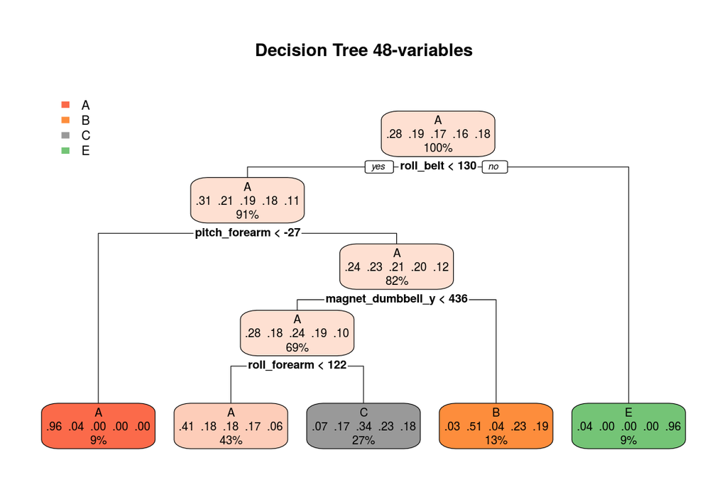

```r
 rpart.plot(decTree2$finalModel, main="Decision Tree 48-variables")
```

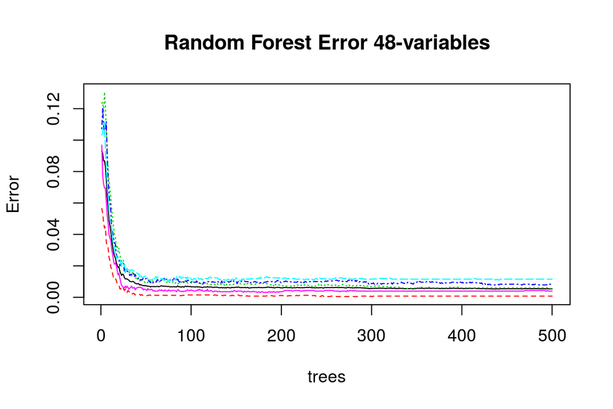

```r
plot(rforest2, main="Random Forest Error 48-variables")
```

### Decision made for the prediction on the test set

We decide to predict the test using the best performing model that is the Random Forest model that uses 48 variables.

This model provides the following categories for the exercises performed.

```r
testPrediciton<-predict(rforest2, newdata=test)
print(testPrediciton)
```

```
##  1  2  3  4  5  6  7  8  9 10 11 12 13 14 15 16 17 18 19 20
##  B  A  B  A  A  E  D  B  A  A  B  C  B  A  E  E  A  B  B  B
## Levels: A B C D E
```

### References

[1] Ugulino, W.; Cardador, D.; Vega, K.; Velloso, E.; Milidiu, R.; Fuks, H. Wearable Computing: Accelerometers’ Data Classification of Body Postures and Movements. Proceedings of 21st Brazilian Symposium on Artificial Intelligence. Advances in Artificial Intelligence - SBIA 2012. In: Lecture Notes in Computer Science. , pp. 52-61. Curitiba, PR: Springer Berlin / Heidelberg, 2012. ISBN 978-3-642-34458-9. DOI: 10.1007/978-3-642-34459-6_6.